# NDVI_Models

Matt Webster

2026-07-28

The purpose of this RMarkdown is to implement hierarchical generalized linear mixed effects models for NDVI ~ damPresence, & NDVI ~ damDensity (with and without geomorphic covariates). Structurally parallel to VegArea ~ dam models.

4 models total.

**Final Data:**

NOTE: This ONLY uses data from 08/15-08/31. This is to avoid issues with pseudo-replication after the omission of random effects for sample event.

Modeling reflects late August effect of beaver dams on NDVI. Green riparian vegetation = mesic resource that is critical for grouse recruitment.

```
## 'data.frame':    676 obs. of  26 variables:
##  $ X               : int  2 6 10 14 18 22 26 30 34 38 ...
##  $ clusterID_seq   : int  1 1 3 3 4 4 5 5 6 6 ...
##  $ window_type     : chr  "dammed" "undammed" "dammed" "undammed" ...
##  $ watershed       : chr  "WC" "WC" "WC" "WC" ...
##  $ year            : int  2019 2019 2019 2019 2019 2019 2019 2019 2019 2019 ...
##  $ catchment_km2   : num  1394 1391 1383 1383 1364 ...
##  $ TO              : num  34.2 35.7 33.2 33.1 45.6 ...
##  $ Nhat            : num  1.13 0 1.13 0 1.13 ...
##  $ t               : int  6 6 6 6 6 6 6 6 6 6 ...
##  $ surveyPeriod    : int  196 196 196 196 196 196 196 196 196 196 ...
##  $ SWA             : num  0 66.7 133.2 332.6 1732.6 ...
##  $ VA              : num  17732 15430 14613 14859 10717 ...
##  $ NDVI            : num  0.359 0.37 0.39 0.347 0.381 ...
##  $ riparian_area_m2: num  2678 2766 2551 2523 3883 ...
##  $ dam_km          : num  4.53 0 4.51 0 4.52 ...
##  $ clusterID_unique: chr  "2019.WC.1" "2019.WC.1" "2019.WC.3" "2019.WC.3" ...
##  $ clusterID_num   : int  16 16 34 34 43 43 52 52 61 61 ...
##  $ stream          : int  6 6 6 6 6 6 6 6 6 6 ...
##  $ sampleEvent     : int  2 2 2 2 2 2 2 2 2 2 ...
##  $ year_id         : int  1 1 1 1 1 1 1 1 1 1 ...
##  $ damPresence     : int  1 0 1 0 1 0 1 0 1 0 ...
##  $ sampleEvent_new : int  2 2 2 2 2 2 2 2 2 2 ...
##  $ logSWA          : num  0 4.21 4.9 5.81 7.46 ...
##  $ y               : int  0 1 1 1 1 1 1 1 1 1 ...
##  $ y_veg           : int  1 1 1 1 1 1 1 1 1 1 ...
##  $ dam_km_std      : num  0.499 -0.94 0.495 -0.94 0.498 ...
```

```
Rough normality of NDVI distribution does not require response transformation prior
to modeling.
```

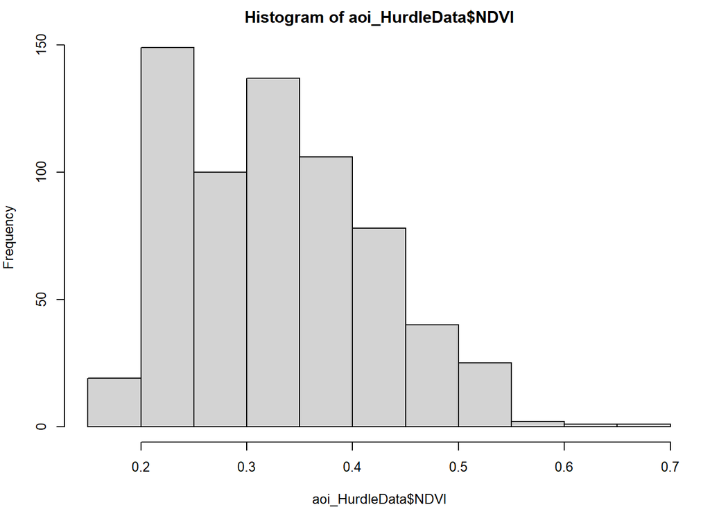

For NDVI models, data of interest include:

```
 - NDVI: average NDVI for sample window[i]; response variable

- stream: index for random intercept on NDVI

- year: index for random intercept on NDVI

- clusterID_seq: index for random intercept on NDVI; represents sample pairing

- damPres: dam presence (0,1); fixed effect on NDVI

- damDen: dams/km; z-standardized ("...$dam_km_std"); fixed effect on NDVI

Only used in models 2 and 4:

- incis: channel incision: 1-(TO/90) (inverse of topographic openness); z-standardized;
  fixed effect on NDVI

- RIPA: riparian area (m^2); z-standardized; fixed effect on NDVI

- UDA: upstream drainage area (km ^2); z-standardized; fixed effect on NDVI
```

**HGLMM**

```
This analysis explores late August vegetation greenness (NDVI) in relation to
beaver dam presence, & density.

2 models for dam presence (1 without geomorphic covariates; 1 with geomorphic covariates)
2 models for dam density (...^^^...)

All 4 models presented herein are constructed in a hierarchical generalized linear
mixed effects model framework with stream, year, and cluster_ID as random intercepts
for NDVI.

  - NDVI ~ damPresence (no geom.covar.)
  - NDVI ~ damPresence (geom.covar.)
  - NDVI ~ damDensity (no geom.covar.)
  - NDVI ~ damDensity (no geom.covar.)

Model structure is paralleled with HGLMMs for veg area.

Uses mean(NDVI) for each sample window for 6 watersheds, 3 years, 08/15-08/31
```

**Overall Takeaways**

```
When we simplify the model, we see that:

Dams have a slightly positive, though MINISCULE effect on NDVI.
```

## NDVI ~ Dam Presence

**Model 1: NDVI ~ DamPresence**

Effect of damPresence without geomorphic covariates

```
sink("HGLMM_m1_NDVI_damPres.jags")

cat("
model{

  # HYPERPRIORS FOR NDVI (1/2 Normal on SDs):

  sigma ~ dnorm(0,1) T(0,)
  tau <- pow(sigma, -2)

  sigma_eta_stream ~ dnorm(0,1) T(0,)
  tau_eta_stream <- pow(sigma_eta_stream,-2)

  sigma_eta_year ~ dnorm(0,1) T(0,)
  tau_eta_year <- pow(sigma_eta_year,-2)

  sigma_eta_cluster ~ dnorm(0,1) T(0,)
  tau_eta_cluster <- pow(sigma_eta_cluster,-2)

  ##########################################################################
  # RANDOM EFFECT PRIORS:

  for(j in 1:n_stream){
    eta_stream[j]  ~ dnorm(0, tau_eta_stream)
  }

  for(j in 1:n_year){
    eta_year[j] ~ dnorm(0, tau_eta_year)
  }

  for(j in 1:n_cluster){
    eta_cluster[j] ~ dnorm(0, tau_eta_cluster)
  }

  ##########################################################################
  # FIXED EFFECT PRIORS:

  alpha ~ dnorm(0.32,0.04)          # within 5 SD of empirical mean NDVI
  beta_damPres ~ dnorm(0,0.04)

  ##########################################################################

  # MAIN LOOP: NDVI

  for(i in 1:N){

    # Amount:
    y[i] ~ dnorm(mu[i], tau)

    mu[i] <- alpha
                + eta_stream[stream[i]]
                + eta_year[year[i]]
                + eta_cluster[cluster[i]]
                + beta_damPres * damPres[i]

  ##########################################################################

  # Derived parameter for WAIC computation:

  loglik[i] <- logdensity.norm(y[i], mu[i], tau)

  }

}
", fill = TRUE)

sink()
```

```
## [1] "2026-08-05 16:12:01 MDT"
```

```
##
## Processing function input.......
##
## Done.
##
## Beginning parallel processing using 3 cores. Console output will be suppressed.
##
## Parallel processing completed.
##
## Calculating statistics.......
##
## Done.
```

```
## [1] "2026-08-05 16:13:14 MDT"
```

DIAGNOSTICS:

Extract posteriors:

“Chain health” Rhat + ESS:

```
## Potential scale reduction factors:
##
##                  Point est. Upper C.I.
## alpha                     1          1
## beta_damPres              1          1
## sigma                     1          1
## sigma_eta_stream          1          1
```

```
##            alpha     beta_damPres            sigma sigma_eta_stream
##         43640.25         44999.11         36463.17         25112.74
```

```
Rhat = 1 & large ESS; looks good for all parameters
```

**Check traceplots** for critical parameters:

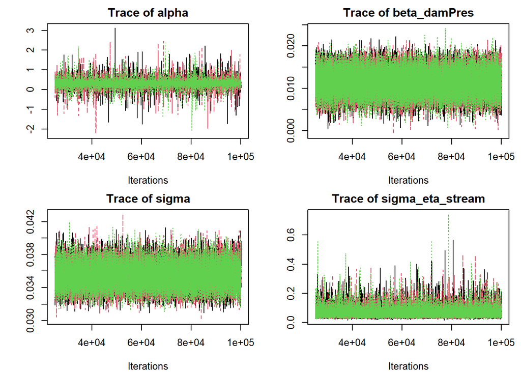

```
Traceplots all look sufficiently grassy, indicating chain convergence.
```

**Posterior predictive plots:**

Model-estimated NDVI vs. observed NDVI

Should be about 1

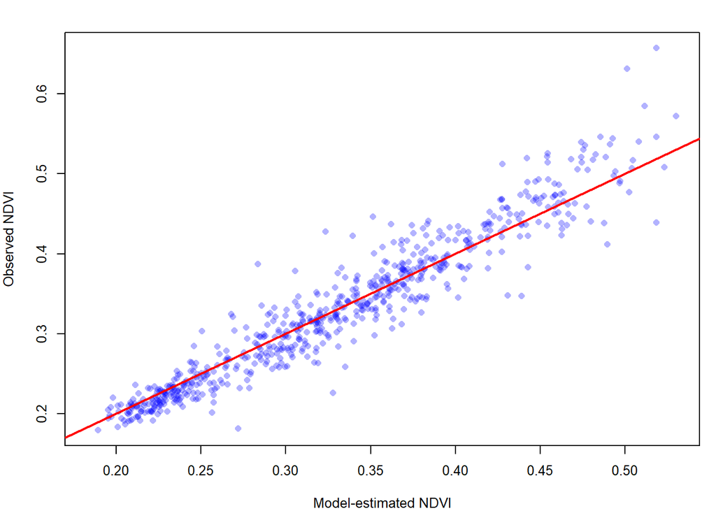

slope =

```
## m1_mu_NDVI_post
##        1.078786
```

```
Comparison of model-estimated NDVI with observed NDVI. "Perfect" model fit would
have a slope = 1. A slope of 1.08 is reasonable, given the model. This indicates
that our model for NDVI is performing fairly well, though slightly underestimating
the variation in NDVI compared to the raw data.
```

**Random effects shrinkage:**

Should be centered around 0(ish)

1. eta_stream; random effect of stream on NDVI intercept (1:6)
2. eta_year; random effect of year on NDVI intercept (1:3)

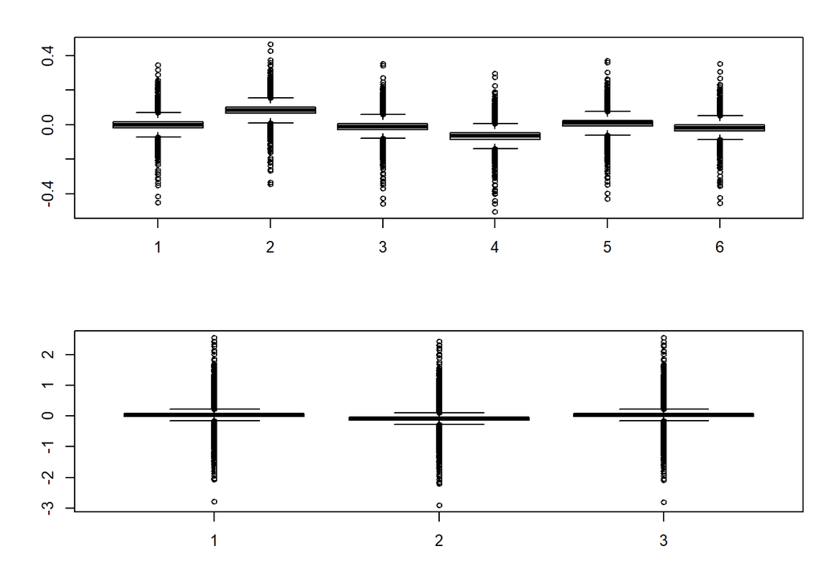

**Posterior mean dam effects:**

NDVI ~ damPres (no geom.covar.)

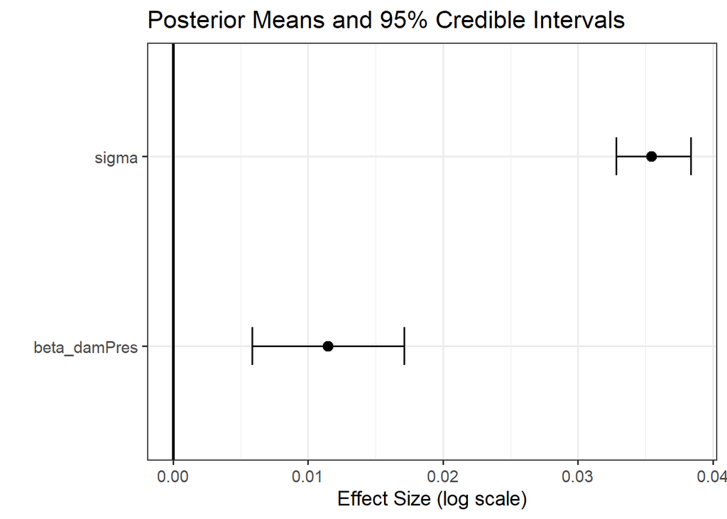

```
##       Min.    1st Qu.     Median       Mean    3rd Qu.       Max.
## -0.0007914  0.0095359  0.0114789  0.0114720  0.0134080  0.0242378
```

```
## [1] 1.011538
```

[figure not shown]

```
Without consideration of geomorphic covariates, dam presence is associated with a
~0.011 increase in NDVI. No overlap of zero. Confidently, a very meager effect.
```

**Prior-posterior overlap:**

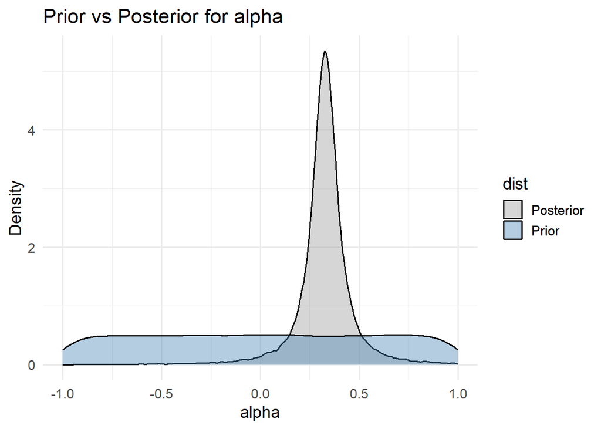

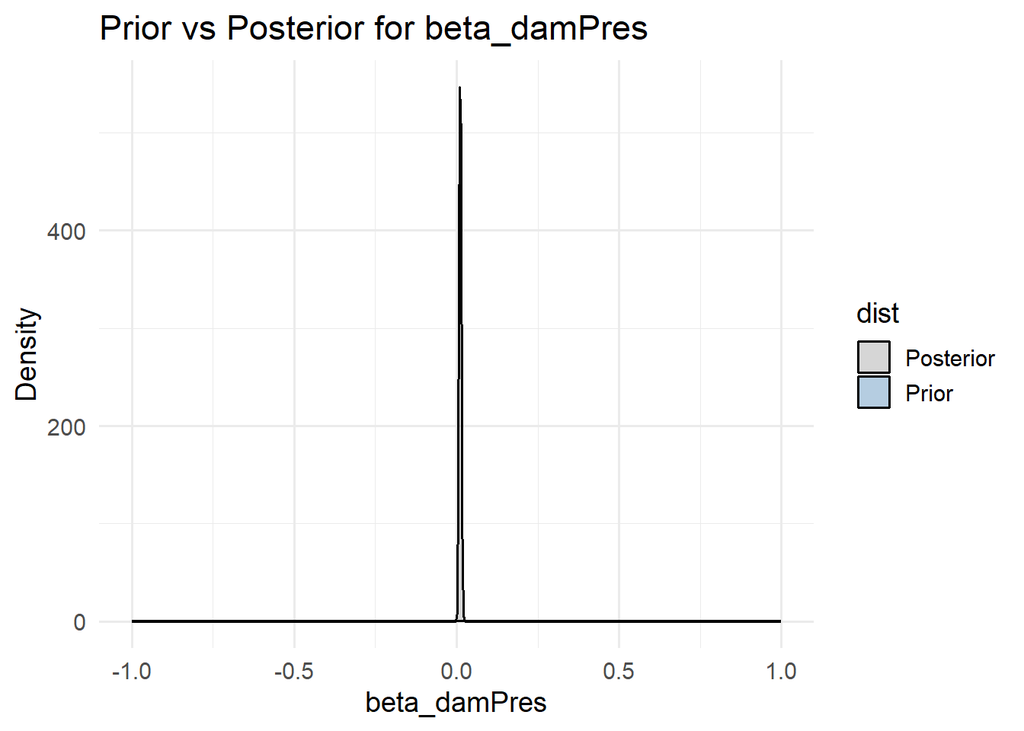

```
PPO indicates that the model is not being driven by prior specifications
```

**Predicted NDVI with and without Dam Presence**

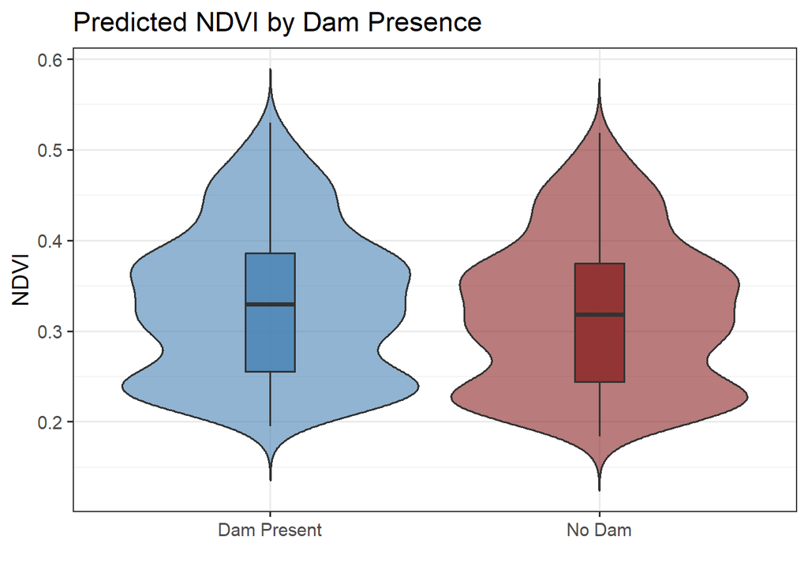

**M2: NDVI ~ damPres + Geom.Covar**

Effect of damPresence WITH geomorphic covariates

```
sink("HGLMM_m2_NDVI_damPres.jags")

cat("
model{

  # HYPERPRIORS FOR NDVI (1/2 Normal on SDs):

  sigma ~ dnorm(0,1) T(0,)
  tau <- pow(sigma, -2)

  sigma_eta_stream ~ dnorm(0,1) T(0,)
  tau_eta_stream <- pow(sigma_eta_stream,-2)

  sigma_eta_year ~ dnorm(0,1) T(0,)
  tau_eta_year <- pow(sigma_eta_year,-2)

  sigma_eta_cluster ~ dnorm(0,1) T(0,)
  tau_eta_cluster <- pow(sigma_eta_cluster,-2)

  ##########################################################################
  # RANDOM EFFECT PRIORS:

  for(j in 1:n_stream){
    eta_stream[j]  ~ dnorm(0, tau_eta_stream)
  }

  for(j in 1:n_year){
    eta_year[j] ~ dnorm(0, tau_eta_year)
  }

  for(j in 1:n_cluster){
    eta_cluster[j] ~ dnorm(0, tau_eta_cluster)
  }

  ##########################################################################
  # FIXED EFFECT PRIORS:

  alpha ~ dnorm(0.32, 0.04)          # within 5 SD of empirical mean NDVI
  beta_damPres ~ dnorm(0,0.04)
  beta_incis ~ dnorm(0,0.04)
  beta_RIPA ~ dnorm(0,0.04)
  beta_UDA ~ dnorm(0,0.04)

  ##########################################################################

  # MAIN LOOP: NDVI

  for(i in 1:N){

    # Amount:
    y[i] ~ dnorm(mu[i], tau)

    mu[i] <- alpha
                + eta_stream[stream[i]]
                + eta_year[year[i]]
                + eta_cluster[cluster[i]]
                + beta_damPres * damPres[i]
                + beta_incis * incis[i]
                + beta_RIPA * RIPA[i]
                + beta_UDA * UDA[i]

  ##########################################################################

  # Derived parameter for WAIC computation:

  loglik[i] <- logdensity.norm(y[i], mu[i], tau)
  }

}
", fill = TRUE)

sink()
```

```
## [1] "2026-08-05 16:13:22 MDT"
```

```
##
## Processing function input.......
##
## Done.
##
## Beginning parallel processing using 3 cores. Console output will be suppressed.
##
## Parallel processing completed.
##
## Calculating statistics.......
##
## Done.
```

```
## [1] "2026-08-05 16:14:47 MDT"
```

DIAGNOSTICS:

Extract posteriors:

“Chain health” Rhat + ESS:

```
## Potential scale reduction factors:
##
##              Point est. Upper C.I.
## alpha                 1          1
## beta_damPres          1          1
## beta_incis            1          1
## beta_RIPA             1          1
## beta_UDA              1          1
## sigma                 1          1
```

```
##        alpha beta_damPres   beta_incis    beta_RIPA     beta_UDA        sigma
##     44566.70     45000.00     44645.66     45000.00     45000.00     35833.23
```

```
Rhats = 1

ESS is high (good) for all parameters
```

**Check traceplots** for critical parameters:

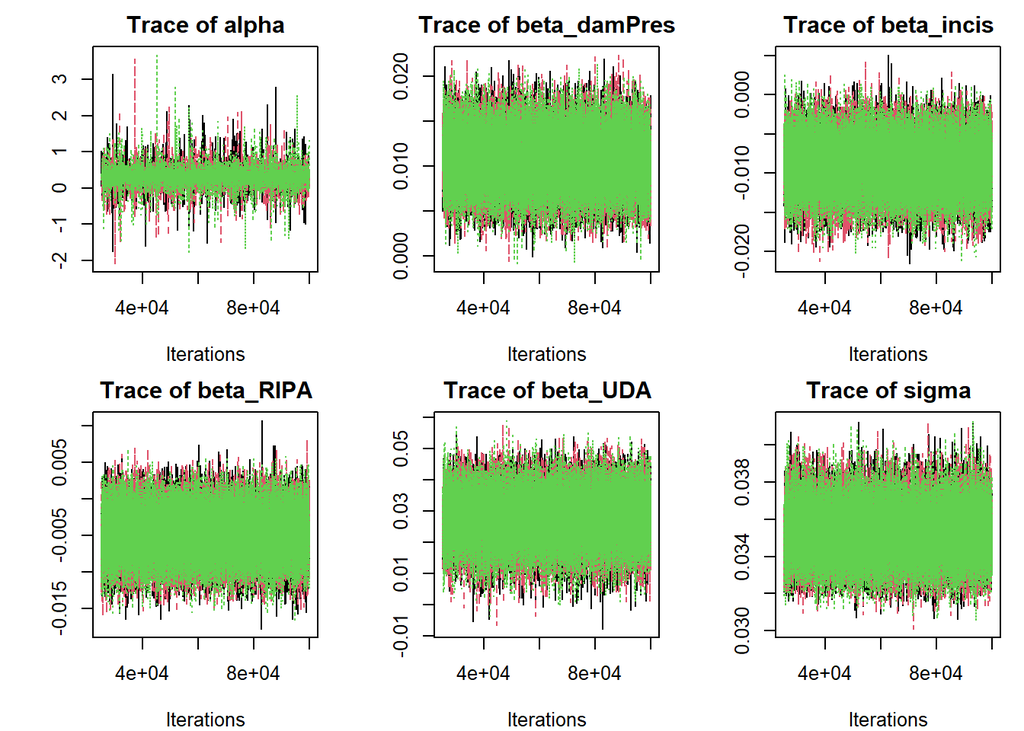

```
Traceplots are sufficiently "grassy"
```

**Posterior predictive plots:**

Should be about 1

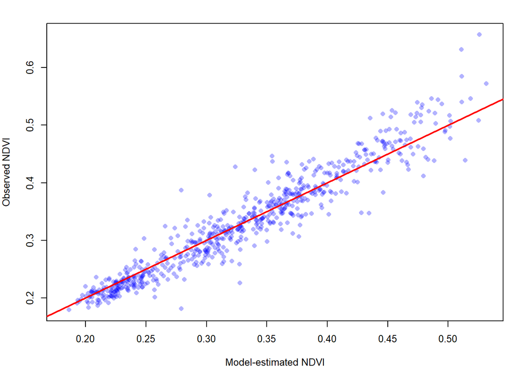

Slope:

```
## m2_mu_NDVI_post
##        1.076889
```

[output not shown]

**Random effects shrinkage:**

Should be centered around 0(ish)

1. eta_stream; random effect of stream on NDVI intercept (1:6)
2. eta_year; random effect of year on NDVI intercept (1:3)

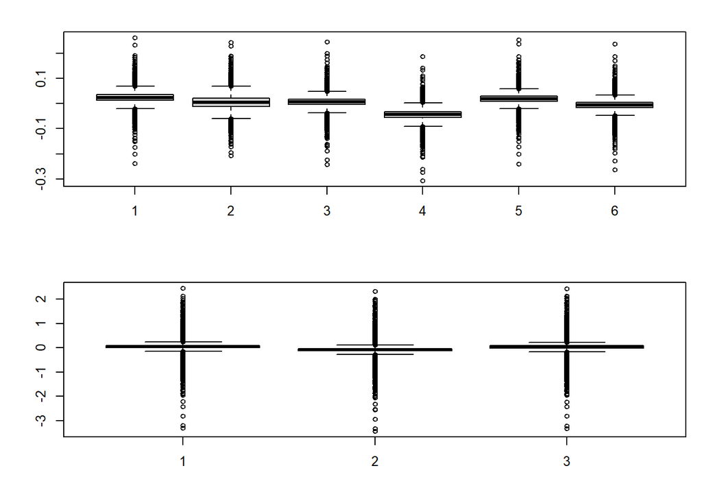

**Posterior mean dam effects:**

damPres -> NDVI (w/geom.covar.)

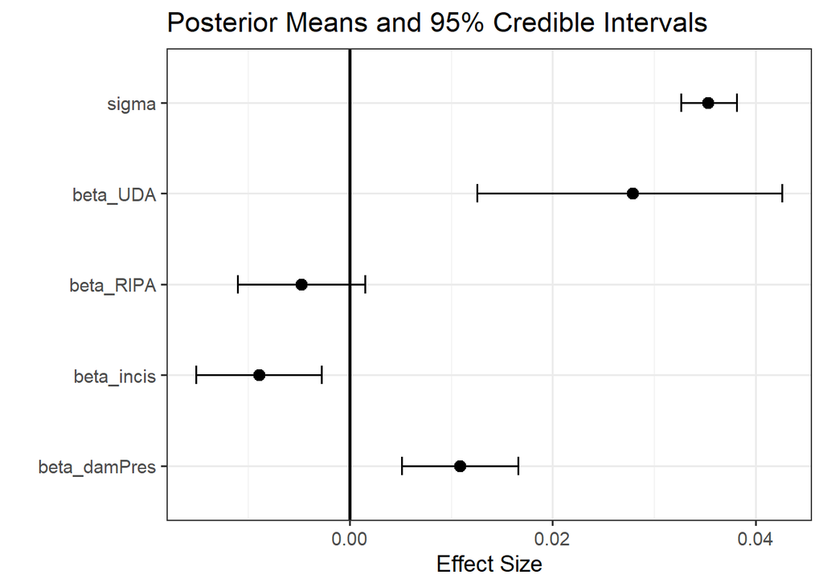

```
##       Min.    1st Qu.     Median       Mean    3rd Qu.       Max.
## -0.0008154  0.0089228  0.0108919  0.0108896  0.0128496  0.0223911
```

```
## [1] 1.010949
```

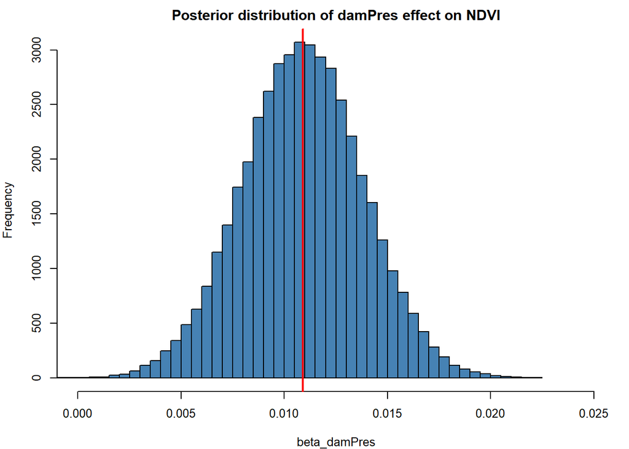

```
When you also consider site-level geomorphic conditions, dam presence is STILL associated
with an estimated 0.01 increase in NDVI.
```

Prior-posterior overlap:

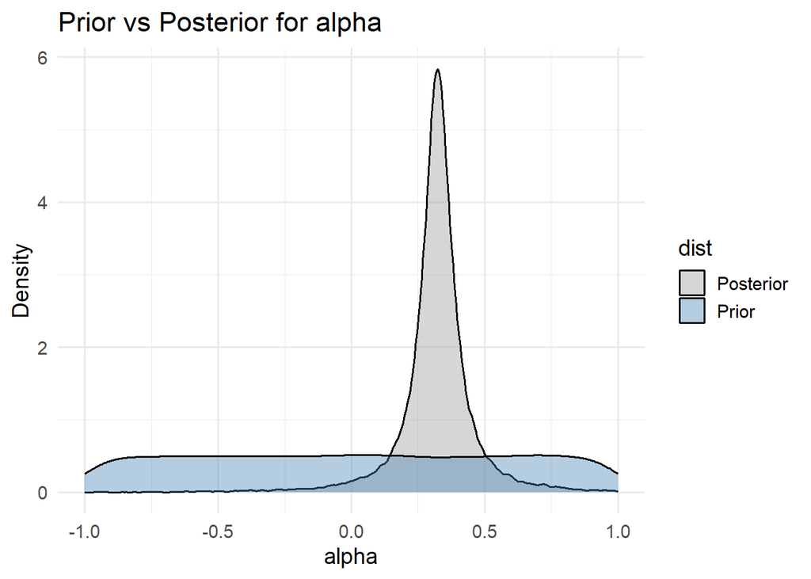

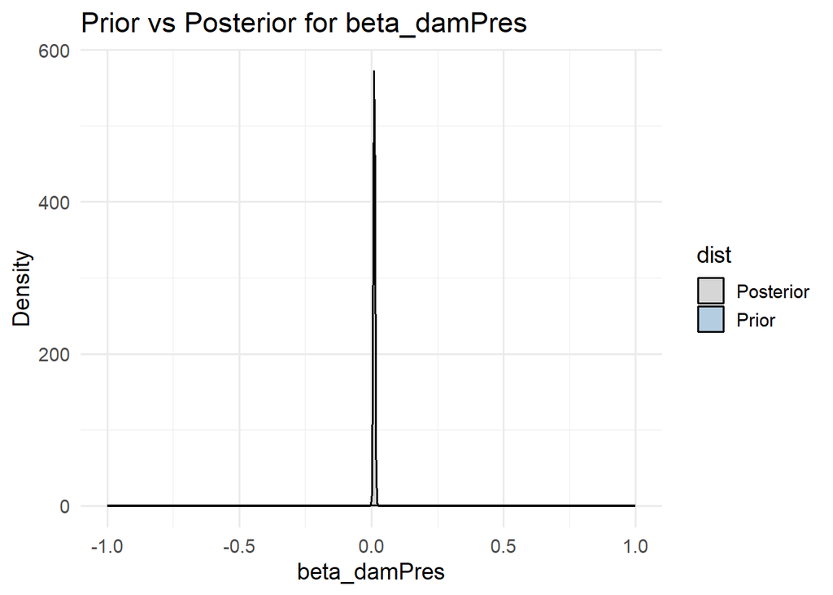

```
PPOs still look pretty good.
```

**Predicted NDVI with and without Dam Presence**

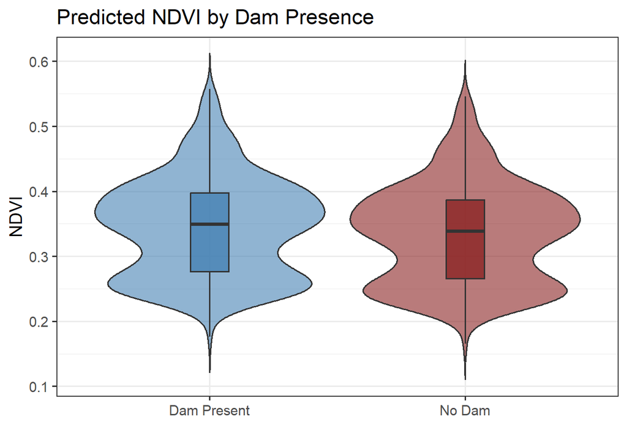

```
Pretty much no difference...
```

**Partial dependence plots**

Constrain PDP to empirical ranges for VA and target covariates

```
##  [1] "mu"                "alpha"             "beta_damPres"
##  [4] "beta_incis"        "beta_RIPA"         "beta_UDA"
##  [7] "eta_stream"        "eta_year"          "eta_cluster"
## [10] "sigma"             "sigma_eta_stream"  "sigma_eta_year"
## [13] "sigma_eta_cluster" "loglik"            "deviance"
```

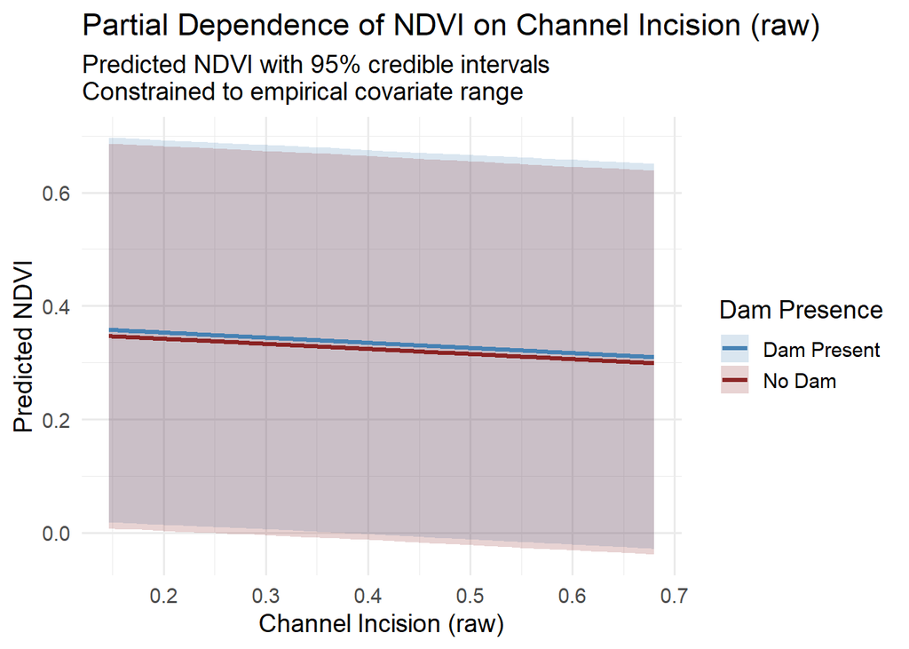

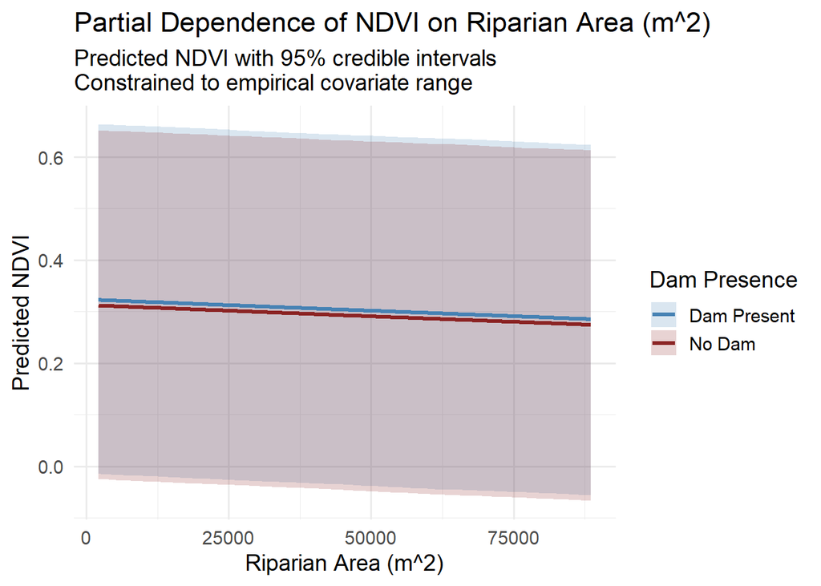

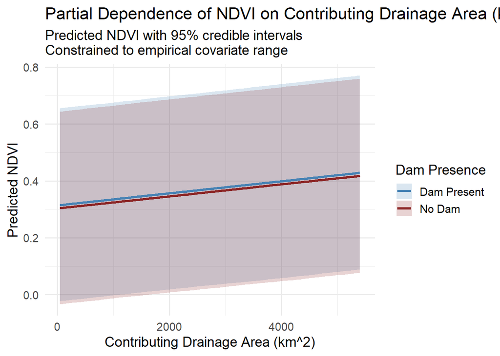

[output not shown]

## NDVI ~ Dam Density

**MODEL 3: NDVI ~ damDensity (no Geom.Covar.)**

```
## [1] "2026-08-05 16:15:04 MDT"
```

```
##
## Processing function input.......
##
## Done.
##
## Beginning parallel processing using 3 cores. Console output will be suppressed.
##
## Parallel processing completed.
##
## Calculating statistics.......
##
## Done.
```

```
## [1] "2026-08-05 16:16:15 MDT"
```

## DIAGNOSTICS:

**Assess “Chain health” Rhat + ESS:**

```
## Potential scale reduction factors:
##
##             Point est. Upper C.I.
## alpha                1          1
## beta_damDen          1          1
## sigma                1          1
```

```
##       alpha beta_damDen       sigma
##    47639.13    45000.00    37291.99
```

```
Rhat & Effective Sample Size:

Rhat values look good.

Effective sample sizes look good
```

**Check traceplots** for critical parameters:

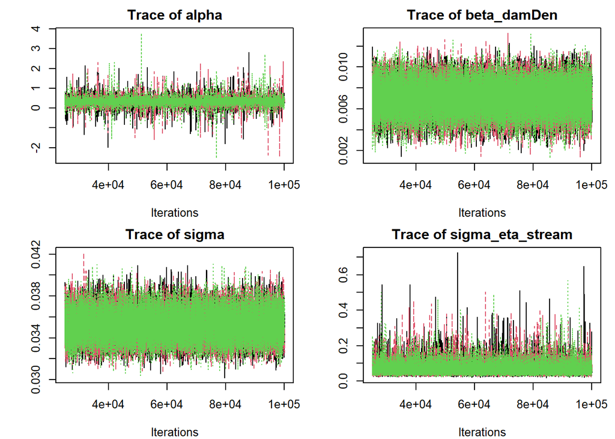

```
Traceplots:

Traceplots all look sufficiently "grassy," indicating chain convergence.
```

**Predicted NDVI vs observed NDVI**

Goal is 1:1 (ish)

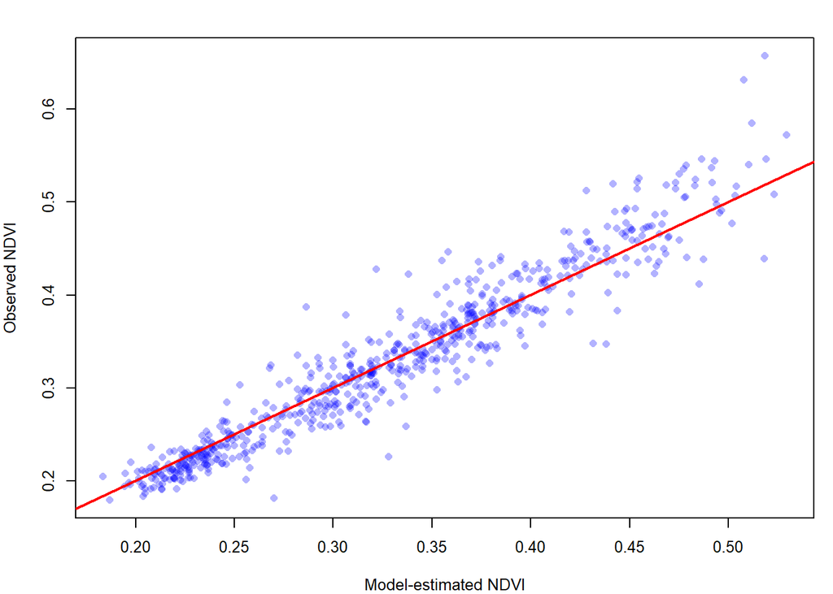

Slope:

```
## m3_mu_NDVI_post
##        1.077525
```

```
1.07 is okay.
```

**Random effects shrinkage:**

Goal is centered around 0(ish)

1. eta_stream; random effect of stream on NDVI intercept; n=6
2. eta_year; random effect of sample event on NDVI intercept; n=3

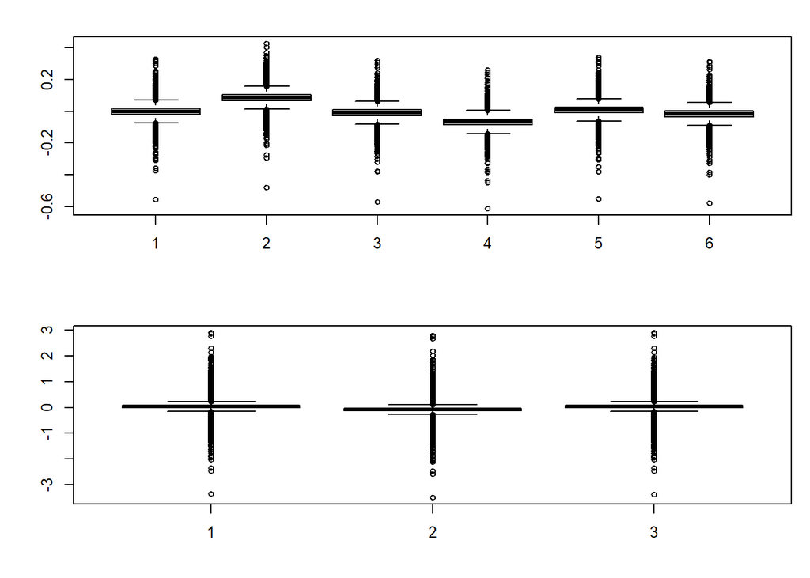

**Posterior mean dam density effect**

damDen –> NDVI (no geom.covar.)

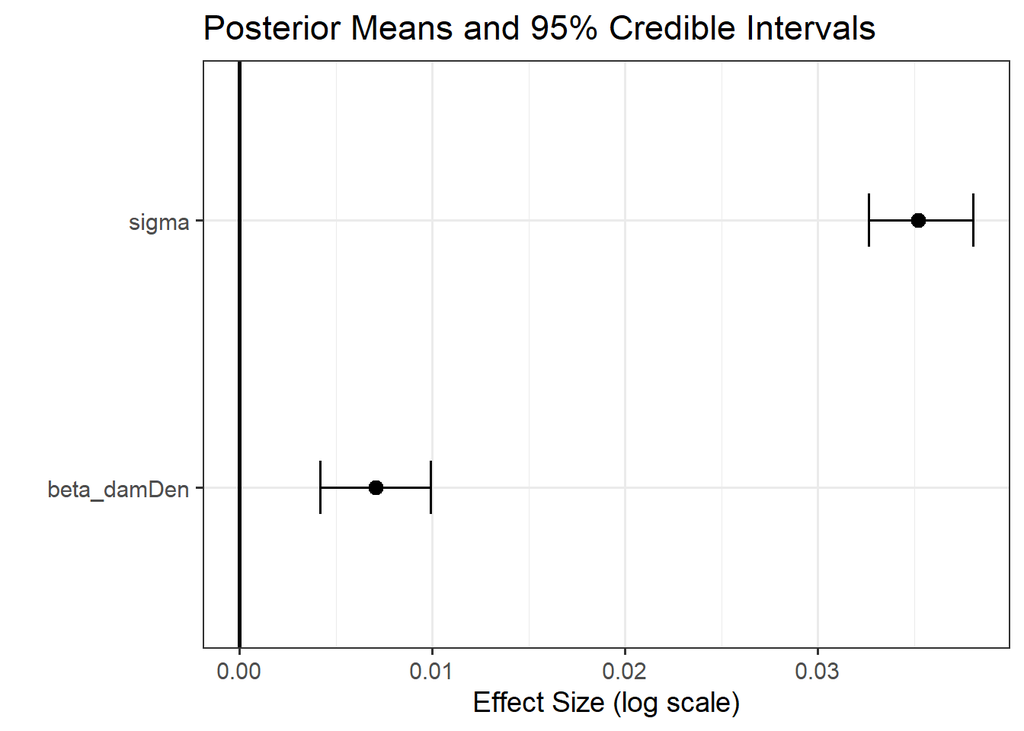

```
##     Min.  1st Qu.   Median     Mean  3rd Qu.     Max.
## 0.001292 0.006068 0.007059 0.007051 0.008032 0.013261
```

```
## [1] 1.007076
```

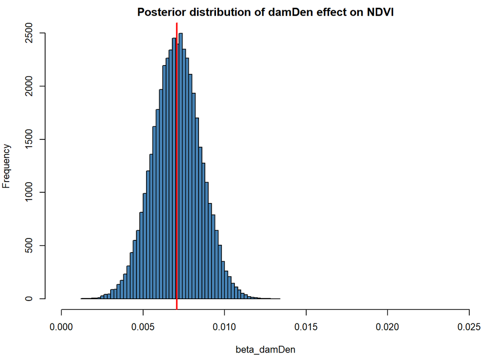

```
Without geomorphic covariates, 1 SD increase in dam density is associated with
0.007 increase in NDVI.... so precisely nothing. Higher dam densities may have
more influence, but we're only talking 0.1 increase or so.
```

**Prior-posterior overlap:**

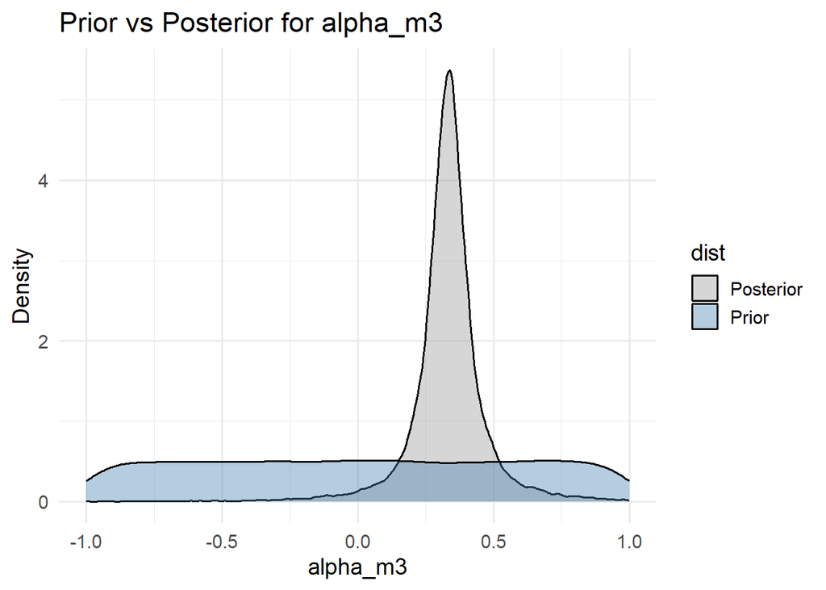

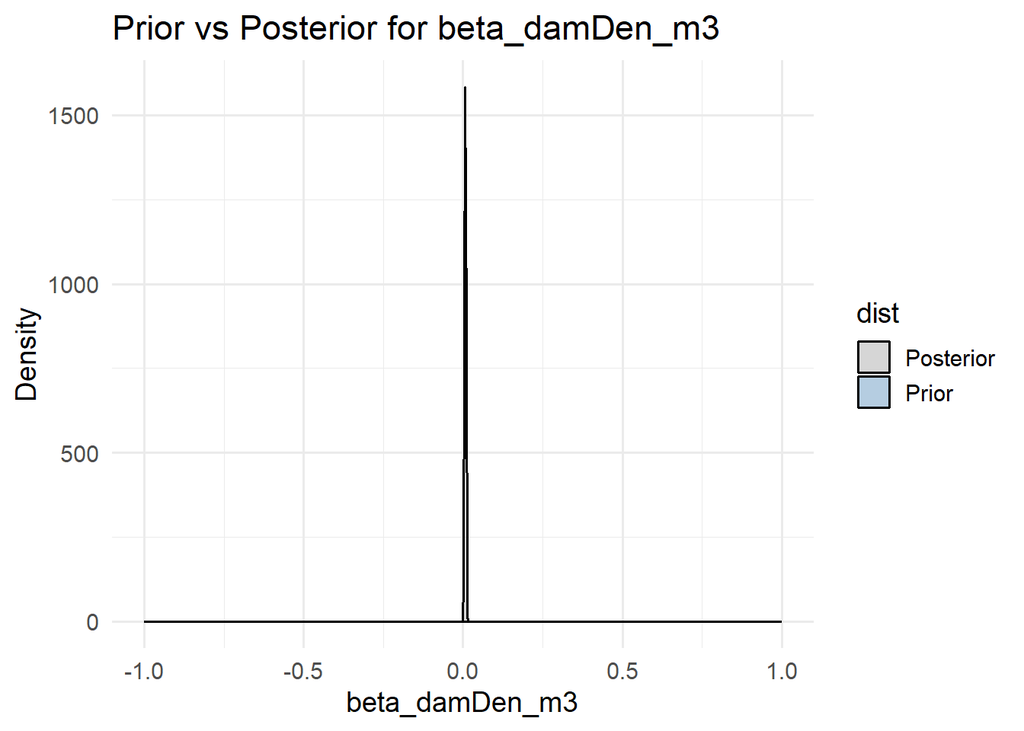

```
PPOs still look pretty good.
```

**Change in NDVI across damDensity by stream and year**

[figure not shown]

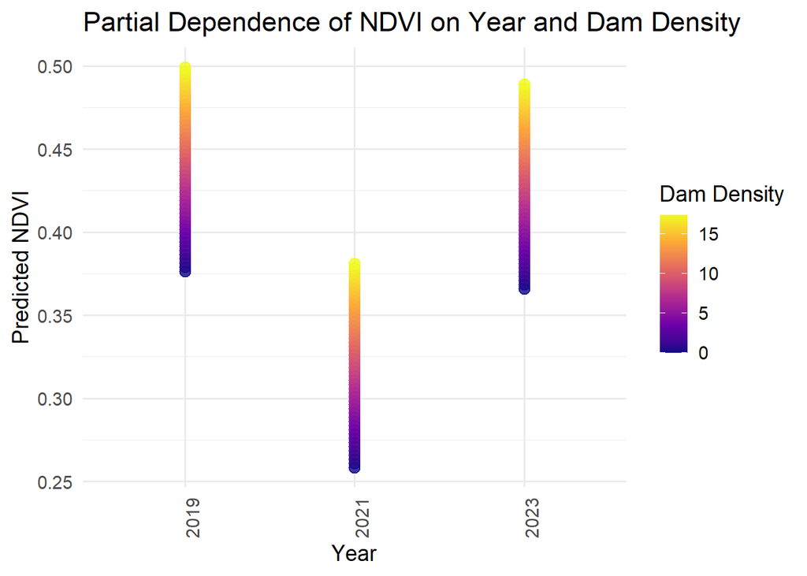

```
## [1] "2026-08-05 16:16:22 MDT"
```

```
##
## Processing function input.......
##
## Done.
##
## Beginning parallel processing using 3 cores. Console output will be suppressed.
##
## Parallel processing completed.
##
## Calculating statistics.......
##
## Done.
```

```
## [1] "2026-08-05 16:17:45 MDT"
```

## DIAGNOSTICS:

**Assess “Chain health” Rhat + ESS:**

```
## Potential scale reduction factors:
##
##                   Point est. Upper C.I.
## alpha                      1          1
## beta_damDen                1          1
## beta_incis                 1          1
## beta_RIPA                  1          1
## beta_UDA                   1          1
## sigma                      1          1
## sigma_eta_stream           1          1
## sigma_eta_year             1          1
## sigma_eta_cluster          1          1
```

```
##             alpha       beta_damDen        beta_incis         beta_RIPA
##          45941.17          45000.00          45755.82          46520.53
##          beta_UDA             sigma  sigma_eta_stream    sigma_eta_year
##          46566.54          35651.39          25522.31          12947.66
## sigma_eta_cluster
##          40918.69
```

[output not shown]

**Check traceplots** for critical parameters:

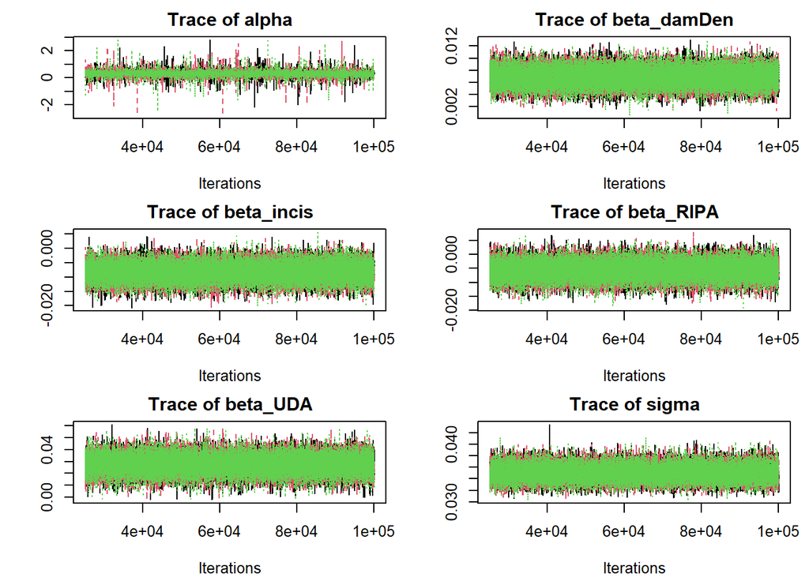

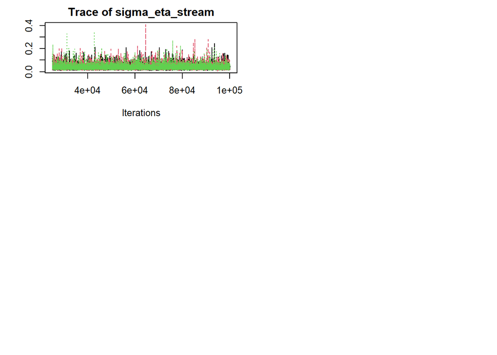

```
Traceplots all look fine.
```

Predicted NDVI vs observed NDVI

Goal is 1:1 (ish)

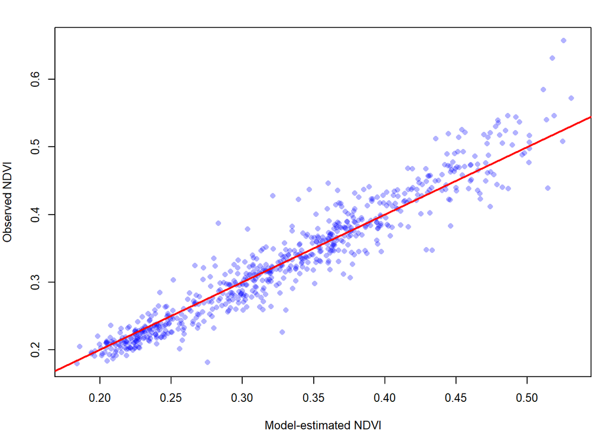

Slope:

```
## m4_mu_NDVI_post
##        1.075919
```

```
1.07 is pretty good
```

**Random effects shrinkage:**

Goal is centered around 0(ish)